# Lecture 5

10 February 2020

## Structure

1. Regression
2. PCA

## Regression

**You tell me…**  
recall you statistics / econometrics class

## Econometric approach

OLS

- statistical method
- assumptions (Gauss-Markov)
  1. linear relationship
     - transformations
  2. zero expected error (\(E(\epsilon_{i}) = 0\))
  3. no perfect multicollinearity (full X matrix rank)
  4. **homoskedasticity** (\(E(\epsilon_{i}^{2}) = const\))

## OLS estimation

\[\hat\beta = (X^{T}X)^{-1}X^{T}y\] **n** observations, **k** variables

- \(X^T \; complextity \; O(nk)\)
- \(X^{T}X = T_{k*k} \; complexity \; O(nk^{2})\)
- \(T^{-1} = U_{k*k} \; complexity \; O(k^{3})\)
- \(UX^{T} = V_{k*n} \; complexity \; O(nk^{2})\)
- \(Vy = W_{k*1} \; complexity \; O(nk)\)
- what if **k** is not small?

## Setup the estimation of the linear relationship

how to uniquely describe a line (2D) ?

- 2 parameters, slope and a point
- there is only 1 parameter to estimate - why?
- \((\bar X,\bar Y)\)
- optimisation task

## (i) random guess

[video not shown]

## (ii) random guess + evolution

- save the parameters and SSR of first iteration - best estimation
- if other parameters lead to lower SSR
  - rewrite the best estimation
- new estimation close to the parameters of the best estimation
- **simplified** MCMC process

## (iii) random guess + evolution + reproduction

1. generate many random “estimates” of slope
2. find the best individuals
   - less then threshold SSR
   - or given number of best-fit individuals
3. let them breed
   - averaging, linear combinations
4. find the best individuals of the extended population
5. repeat 3. and 4. until convergence / stopping condition
- simple evolution algorithm

## Evolution estimation

[video not shown]

## (iv) gradient descent

1. calculate the gradient of the function
   - \(SSR = \sum_i (y_{i} - \hat y_{i})^{2} = \sum_i (y_{i} - (a + bx_{i}))^{2} =\)  
     \(\sum_i (y_{i} - (\overline y - b \overline x) - bx_{i})^{2} = \sum_i (y_{i} - \overline y - b(x_{i} - \overline x))^{2}\)
   - \(\frac{\nabla SSR}{n} = \frac{\partial SSR}{\partial b} * \frac{1}{n} = H(b)\)
2. generate initial random “estimate” of slope = \(b_{0}\)
3. move a little in the direction of the gradient
   - \(b_{n} = b_{n-1} - \alpha H(b)\)
   - \(\alpha = parameter\)
4. repeat 3. until convergence / stopping condition

## Differences

- for the purpose of fitting the linear relationship (no inference)
  - no assumptions
- for inference (prediction)
  - mostly care about homoskedasticity & outliers
    - different error function
  - cross-validation
  - bagging / boosting
- watch out for local optimas!
  - ABC optimisation

## PCA

## Principal Component Analysis

- data transformation method
  - correlated variables into uncorrelated
- useful for dimension reduction
- produces new orthogonal “variables”
  - linear combination of the original ones
- how would you estimate that?
- similar to linear model
- different error function
- why do we want to do this?

## Linear Algebra

- projections and multiplication
- eigen - vectors & values

## Components

- basically the unit eigenvectors of covariance matrix
- new “axes”
- sorted according to amount of variance explained
  - proportion of explained variance equals proportion of eigenvalues
  - first component captures the highest amount of variance
  - dimension reduction = choosing \(k\) components

## Calculating eigen-decomposition

```r
(mtcars[,3:4] %>% scale %>% assign("scaled", ., pos = 1) %>% cov %T>% print %>%
   eigen -> eg)
```

```
##           disp        hp
## disp 1.0000000 0.7909486
## hp   0.7909486 1.0000000
```

```
## eigen() decomposition
## $values
## [1] 1.7909486 0.2090514
##
## $vectors
##           [,1]       [,2]
## [1,] 0.7071068 -0.7071068
## [2,] 0.7071068  0.7071068
```

## Graphically

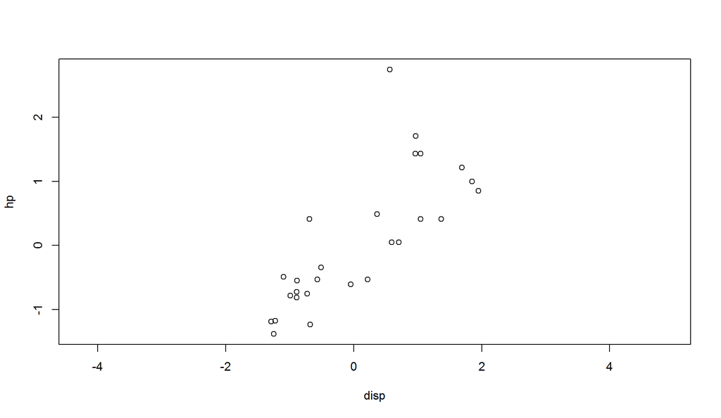

## Eigenvectors

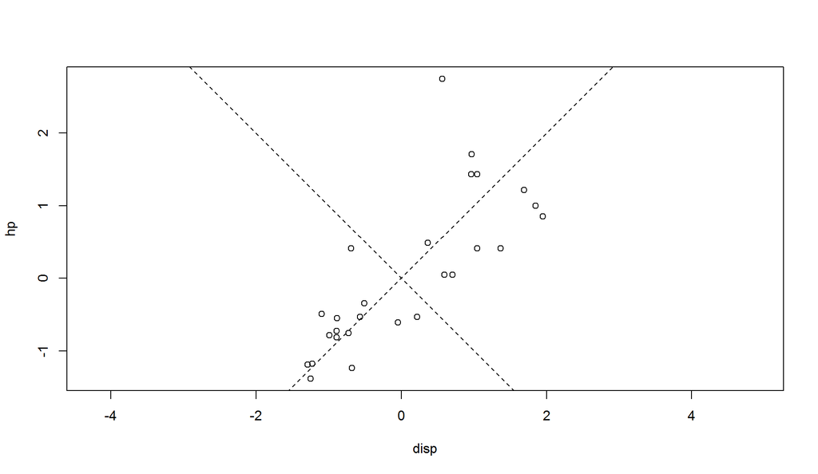

## Components

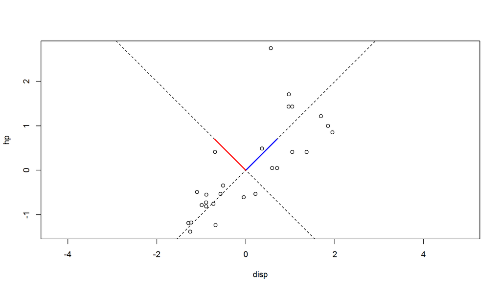

## Reduced to 1D

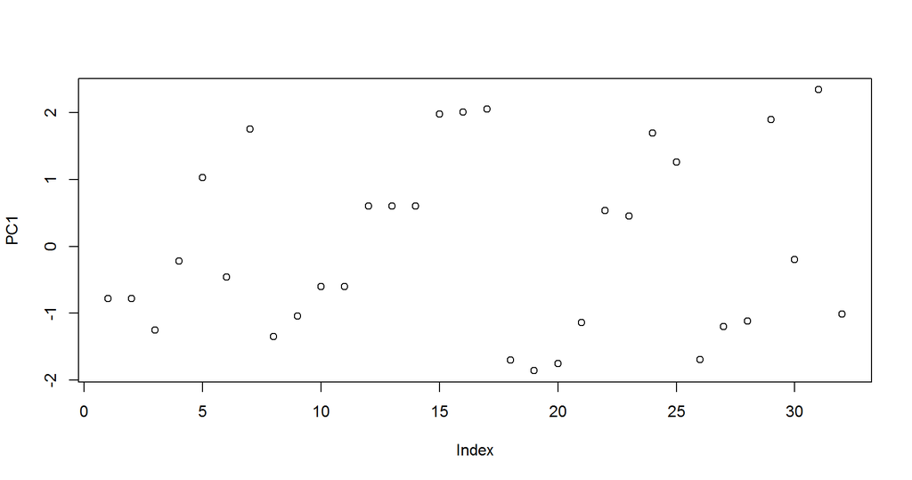

```r
{scaled %*% eg$vectors[,1]} %>% plot(ylab = "PC1")
```

## Compared with implemented function

- stats::prcomp()
  - using SVD, minor differences

```
## eigen() decomposition
## $values
## [1] 1.7909486 0.2090514
##
## $vectors
##           [,1]       [,2]
## [1,] 0.7071068 -0.7071068
## [2,] 0.7071068  0.7071068
```

```
## Standard deviations (1, .., p=2):
## [1] 1.3382633 0.4572214
##
## Rotation (n x k) = (2 x 2):
##            PC1        PC2
## disp 0.7071068 -0.7071068
## hp   0.7071068  0.7071068
```

## Plotting PCs

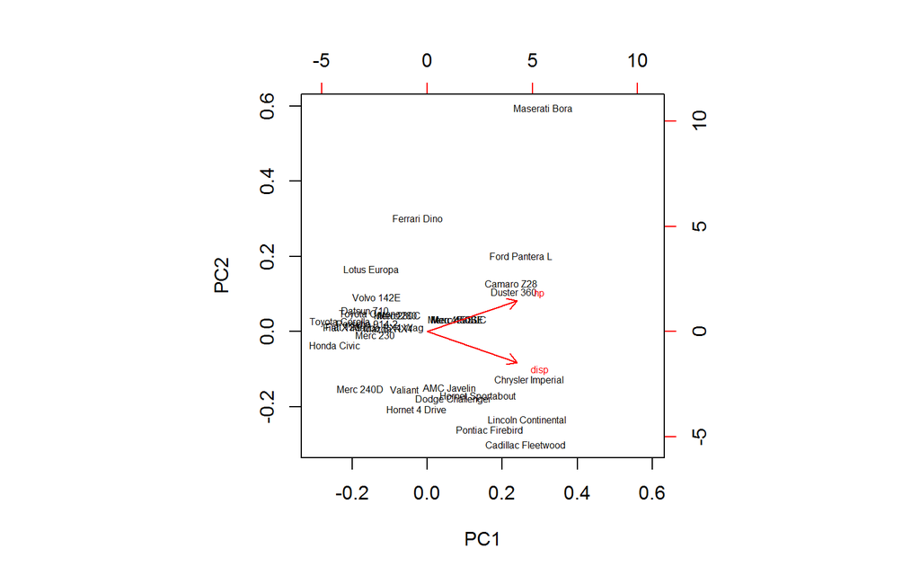

## Math behind - eigenvalue ~ explained variance

\(C = covariance \; matrix \; k \times k\)  
\(w = vector, k \times 1, ||w|| = 1\)  
\(\lambda \in R\)

Lagrange, maximise  
\(L = w^{T}Cw - \lambda(w^{T}w - 1)\)  
\(\frac{\partial L}{\partial w} = 0 \Rightarrow Cw - \lambda w =0\)

Substitute back \(w^{T}Cw - \lambda(w^{T}w-1) = w^{T}Cw = \lambda w^{T} w = \lambda\)